# FantasyFootballProject

Lance Elliott

2025-03-02

## Introduction

Link to dataset via nflverse GitHub repository: https://github.com/nflverse/nflverse-data/releases/download/player_stats/player_stats_season_2024.rds

Dataset consists of 1370 observations of 52 variables. Each observation is one NFL player. The 52 variables consist of: - nominal variables such as the NFL player’s name, a unique ID, the team who rostered the player, the position they played at on that team, and a URL to a headshot of the player - numeric variables such as the amount of games the player appeared, positional statistics like passing attempts, passing completions, passing/rushing/receiving yards, and passing/rushing/receiving touchdowns - the discrete variables standard and point per reception (PPR) fantasy points - continuous variables like positional EPAs, PACR, Dakota, and other composite data

Motivations for choosing this dataset are a complete picture of the 2024 season with which I could analyze to give further insight into my personal hobby of fantasy football.

## Filtering, mutation, and selection of fantasy football related statistics

The following code block filters for NFL positions which comprise a fantasy football team, mutates per game statistics and net statistics to clarify point calculations, and deselects variables which do not contribute to point calculations.

```r
nfl_stats <- nfl_stats %>%
  filter(position_group %in% c("QB", "RB", "WR", "TE"),
         season_type == "REG") %>%
  mutate(passing_yards_per_game = passing_yards / games,
         passing_tds_per_game = passing_tds / games,
         net_rushing_yards = rushing_yards - sack_yards,
         fumbles_lost = sack_fumbles_lost + rushing_fumbles_lost + receiving_fumbles_lost,
         converted_passing_air_yards = passing_yards - passing_yards_after_catch,
         rushing_yards_per_game = rushing_yards / games,
         rushing_tds_per_game = rushing_tds / games,
         receiving_yards_per_game = receiving_yards / games,
         receiving_tds_per_game = receiving_tds / games,
         receiving_air_yards_per_game = receiving_air_yards / games,
         fantasy_points_per_game = fantasy_points_ppr / games,
         targets_per_game = targets / games) %>%
  select(-season, -player_name, -season_type, -player_id, -player_display_name, -position, -headshot_url, -recent_team, -completions, -attempts, -sack_fumbles, -passing_first_downs, -passing_2pt_conversions, -carries, -rushing_fumbles, -rushing_first_downs, -rushing_2pt_conversions, -receiving_fumbles, -receiving_first_downs, -receiving_2pt_conversions, -special_teams_tds, -fantasy_points, -passing_epa, -rushing_epa, -receiving_epa, -dakota)
```

To filter out players who did not play regularly and might skew the data with outliers, I mutated a variable for the mean games played by a NFL player in the 2024 season and filtered for those who played at least the floor of the mean games played.

```r
mean_games <- mean(nfl_stats$games)
nfl_stats <- nfl_stats %>%
  mutate(reg_player = if_else(games >= floor(mean_games), TRUE, FALSE)) %>%
  filter(reg_player == TRUE) %>%
  select(-games, -reg_player)
```

In order to tailor the datset to only fantasy rosterable players, I used the standard roster construction, 1 QB, 2 RB, 2 WR, 1 TE, to find the top fantasy players for each NFL team.

```r
nfl_stats <- nfl_stats %>%
  group_by(position_group) %>%
  mutate(rank_fppg = rank(-fantasy_points_per_game)) %>%
  ungroup() %>%
  mutate(fantasy_rosterable =  case_when(
    position_group == "QB" & rank_fppg <= 32 ~ TRUE,
    position_group == "RB" & rank_fppg <= 64 ~ TRUE,
    position_group == "WR" & rank_fppg <= 64 ~ TRUE,
    position_group == "TE" & rank_fppg <= 32 ~ TRUE,
    TRUE ~ FALSE
  )) %>%
  filter(fantasy_rosterable == TRUE) %>%
  select(-rank_fppg, -fantasy_points_ppr, -fantasy_rosterable)
```

The goal of this project was to provide insights into optimal fantasy roster construction. Exploratory analysis began by creating a boxplot of fantasy positions and their fantasy points per game (FPPG).

## Boxplot analyzing positional value

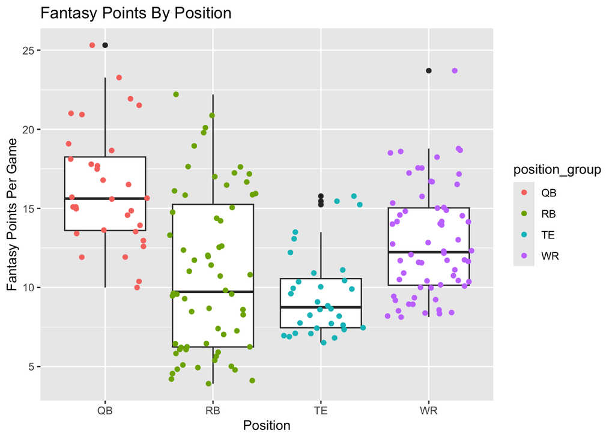

```r
fantasy_points_boxplot <- ggplot(nfl_stats, aes(position_group, fantasy_points_per_game)) +
  geom_boxplot() +
  geom_jitter(aes(color = position_group)) +
  labs(
    title = "Fantasy Points By Position",
    x = "Position",
    y = "Fantasy Points Per Game"
  )
print(fantasy_points_boxplot)
```

I then summarized the data to help identify positional value:

```r
position_variability <- nfl_stats %>%
  group_by(position_group) %>%
  summarise(
    Q1 = quantile(fantasy_points_per_game, 0.25),
    Q3 = quantile(fantasy_points_per_game, 0.75),
    IQR = Q3 - Q1,
    mean = mean(fantasy_points_per_game)
  )

position_variability
```

```
## # A tibble: 4 × 5
##   position_group    Q1    Q3   IQR  mean
##   <chr>          <dbl> <dbl> <dbl> <dbl>
## 1 QB             13.6   18.3  4.65 16.3
## 2 RB              6.24  15.3  9.01 10.9
## 3 TE              7.45  10.6  3.10  9.56
## 4 WR             10.1   15.0  4.89 12.9
```

# Interpretations:

The resulting box plot and summary identified: - QBs accounted for the highest mean points per game of 16. - RBs accounted for the highest variability between the 1st and 3rd quartiles of 9 points per game. - WRs were second in both mean and variability. - TEs accounted for the lowest mean and variability among all positions.

The next step would be to insure that FPPG was normally distributed across positional groups, if a histogram of each position showed this to be true, then FPPG should be the focus of my report.

## Histograms of distributions of FPPG across positions

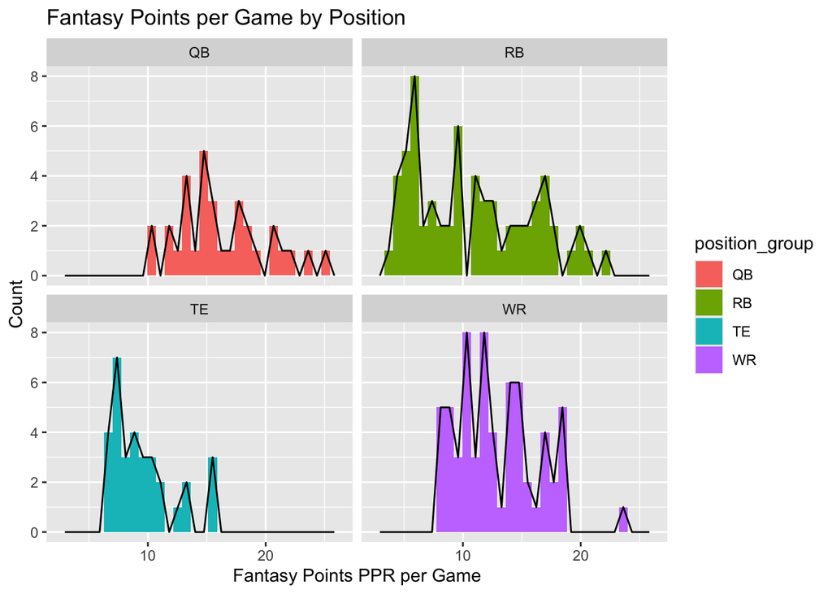

```r
fantasy_points_per_position_histogram <- nfl_stats %>%
ggplot(aes(x = fantasy_points_per_game, fill = position_group)) +
  geom_histogram(bins = 30) +
  geom_freqpoly() +
  facet_wrap(~position_group) +
  labs(title = "Fantasy Points per Game by Position",
       x = "Fantasy Points PPR per Game",
       y = "Count")

print(fantasy_points_per_position_histogram)
```

# Interpretations:

- While not perfect bell curves, the histograms indicated that I could continue with points per game being the focal point of my analysis.
- Since QB’s provided the highest mean points per game, asking the question “what makes a good fantasy QB?” would be the focus of my hypothesis.

## Creating a dataset which focuses on QB observations and relevant variables

```r
qb_stats <- nfl_stats %>%
  filter(position_group == "QB") %>%
  select(-position_group, -receptions, -targets, -receiving_yards, -receiving_tds, -receiving_fumbles_lost, -receiving_air_yards, -receiving_yards_after_catch, -racr, -target_share, -air_yards_share, -wopr, -receiving_yards_per_game, -receiving_tds_per_game, -receiving_air_yards_per_game, -targets_per_game)
```

To identify which variables had the highest correlation with fantasy points, I used a correlation matrix across all variables.

```r
correlation_matrix <- qb_stats %>%
  select(-fantasy_points_per_game) %>%
  summarise(across(everything(), ~ cor(. , qb_stats$fantasy_points_per_game)))

correlation_matrix
```

```
## # A tibble: 1 × 19
##   passing_yards passing_tds interceptions sacks sack_yards sack_fumbles_lost
##           <dbl>       <dbl>         <dbl> <dbl>      <dbl>             <dbl>
## 1         0.658       0.784       -0.0367 0.127     0.0433           -0.0173
## # ℹ 13 more variables: passing_air_yards <dbl>,
## #   passing_yards_after_catch <dbl>, pacr <dbl>, rushing_yards <dbl>,
## #   rushing_tds <dbl>, rushing_fumbles_lost <dbl>,
## #   passing_yards_per_game <dbl>, passing_tds_per_game <dbl>,
## #   net_rushing_yards <dbl>, fumbles_lost <dbl>,
## #   converted_passing_air_yards <dbl>, rushing_yards_per_game <dbl>,
## #   rushing_tds_per_game <dbl>
```

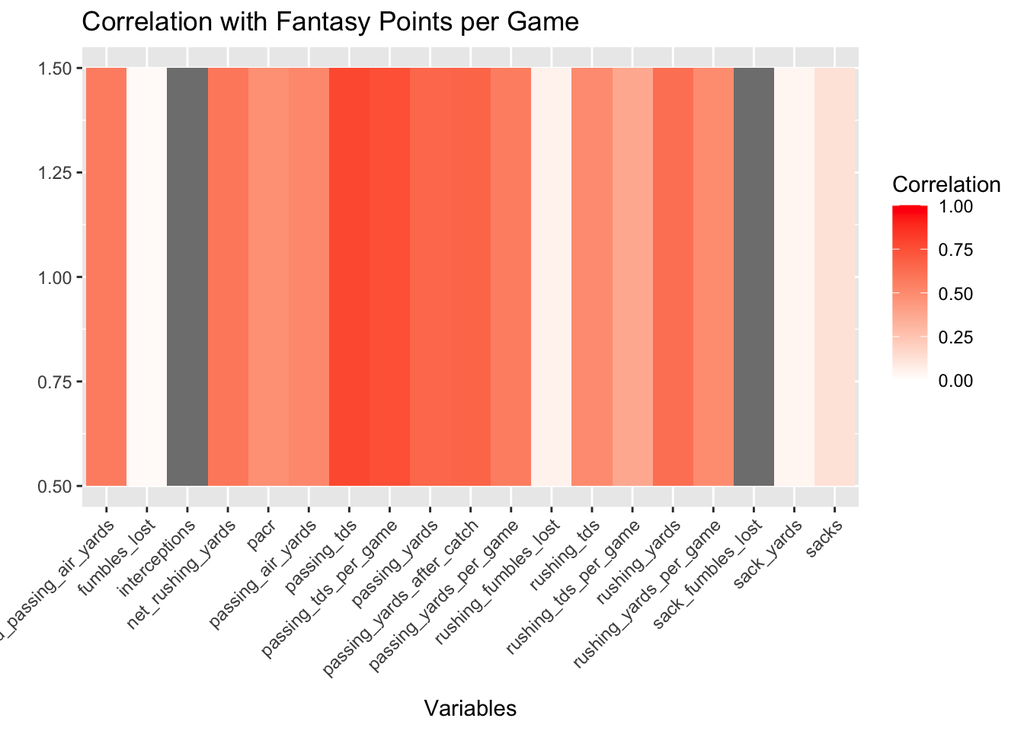

```r
correlation_melted <- correlation_matrix %>%
  pivot_longer(cols = everything(), names_to = "Variable", values_to = "Correlation")

qb_fantasy_point_correllation_matrix <- ggplot(correlation_melted, aes(x = Variable, y = 1, fill = Correlation)) +
  geom_tile() +
  scale_fill_gradient2(low = "blue", high = "red", mid = "white", midpoint = 0, limit = c(0, 1)) +
  labs(title = "Correlation with Fantasy Points per Game",
       x = "Variables",
       y = "") +
  theme(axis.text.x = element_text(angle = 45, hjust = 1))

print(qb_fantasy_point_correllation_matrix)
```

# Interpretations

According to the correlation matrix, the variables most closely associated with what makes a good fantasy QB are passing touchdowns and passing yards. This is not surprising, as that is the primary role of a quarterback.

I instead chose to look for a variable which might not be apparent to most fans and found rushing yards to provide a high correlation as well.

## Scatter plot with a regression line

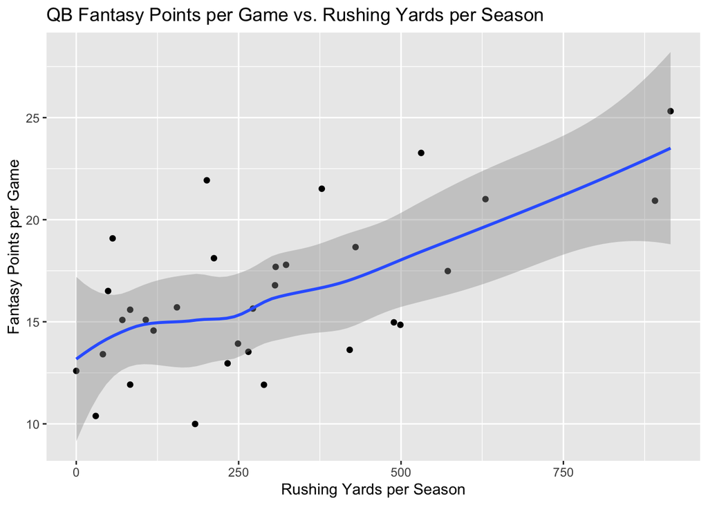

```r
qb_fppg_rushing <- ggplot(qb_stats, aes(x = rushing_yards, y = fantasy_points_per_game)) +
  geom_point() +
  geom_smooth() +
  labs(title = "QB Fantasy Points per Game vs. Rushing Yards per Season",
       x = "Rushing Yards per Season",
       y = "Fantasy Points per Game")

print(qb_fppg_rushing)
```

# Analysis of linear regression model

```r
model <- lm(fantasy_points_per_game ~ rushing_yards, data = qb_stats)

summary(model)
```

```
##
## Call:
## lm(formula = fantasy_points_per_game ~ rushing_yards, data = qb_stats)
##
## Residuals:
##     Min      1Q  Median      3Q     Max
## -5.2182 -2.3485  0.1732  1.3619  6.5388
##
## Coefficients:
##                Estimate Std. Error t value Pr(>|t|)
## (Intercept)   13.397270   0.849034  15.779 4.53e-16 ***
## rushing_yards  0.009923   0.002274   4.364 0.000139 ***
## ---
## Signif. codes:  0 '***' 0.001 '**' 0.01 '*' 0.05 '.' 0.1 ' ' 1
##
## Residual standard error: 2.97 on 30 degrees of freedom
## Multiple R-squared:  0.3883, Adjusted R-squared:  0.3679
## F-statistic: 19.05 on 1 and 30 DF,  p-value: 0.0001392
```

# Interpretations

- The intercept represents the mean number of points per game a QB will account for without a single rushing yard – 13.4 points.
- The slope of the line is 0.01, which is exactly how many points a rushing yard is worth, so no surprises there.
- A t-value represents the strength of the effect of rushing yards on fantasy points per game, meaning it is over 4 times the randomness in the data.
- The p-value is very low, which tells us the relationship between rushing yards and points per game.
- An adjusted R-squared of .36 represents rushing yardage accounts for over 1/3 of the variability in points per game

## Mutating the dual-threat quarterback binary variable

Our null hypothesis will be that there is no difference between QBs who rush the ball well and those who do not. To perform a welch two sample t-test, I mutated a binary variable which represents rushing quarterbacks.

The mutated the binary variable dual-threat, based upon whether a QB accumulated one standard deviation above the mean rushing yards for a QB.

```r
mean_qb_rush <- mean(qb_stats$rushing_yards)
sd_qb_rush <- sd(qb_stats$rushing_yards)
rushing_qb_threshold <- mean_qb_rush + sd_qb_rush
qb_stats <- qb_stats %>%
  mutate(dual_threat = if_else(rushing_yards >= floor(rushing_qb_threshold), TRUE, FALSE))
```

## Dual-threat QB boxplot

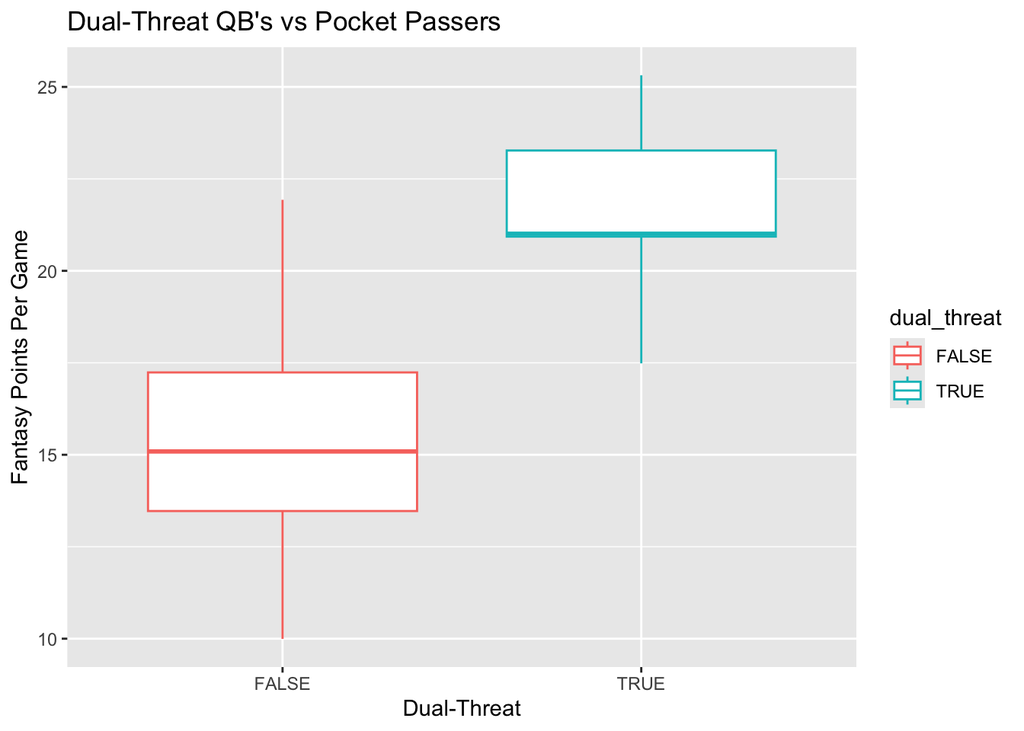

```r
dual_threat_boxplot <- ggplot(qb_stats, aes(dual_threat, fantasy_points_per_game)) +
  geom_boxplot(aes(color = dual_threat)) +
  labs(
    title = "Dual-Threat QB's vs Pocket Passers",
    x = "Dual-Threat",
    y = "Fantasy Points Per Game"
  )
print(dual_threat_boxplot)
```

## Interpretations

The boxplot reinforces the separation between dual-threat quarterbacks and pocket passers when accounting for fantasy points per game.

## Welch two sample t-test

```r
t_test_result <- t.test(fantasy_points_per_game ~ dual_threat, data = qb_stats)

t_test_result
```

```
##
##  Welch Two Sample t-test
##
## data:  fantasy_points_per_game by dual_threat
## t = -4.3837, df = 5.6584, p-value = 0.00534
## alternative hypothesis: true difference in means between group FALSE and group TRUE is not equal to 0
## 95 percent confidence interval:
##  -9.826974 -2.719828
## sample estimates:
## mean in group FALSE  mean in group TRUE
##             15.3288             21.6022
```

# Interpretations

A low p-value tells us this is statistically significant, and with a difference in means of greater than 6 points per game, the difference is substantial.

## Conclusion

We reject the null hypothesis, the value of a dual-threat QB is both significant and substantial compared to a pure passer. In terms of fantasy football relevance, with all other statistics being equal, it is beneficial to roster a QB which has a higher expected rushing yard total.